# Estadística Descriptiva Multivariada

Análisis de Componentes Principales

Jimmy A Corzo S, PhD

jacorzos@unal.edu.co

Giovany Babativa-Márquez, PhD

jgbabativam@unal.edu.co

# Panorama de la Estadística Descriptiva Multivariada en el moderno contexto del aprendizaje estadístico no supervisado

## **Objetivo de los métodos supervisados**

### Predecir una variable respuesta $Y$ a partir de predictores $X_1, \ldots, X_p$ mediante un modelo

$$Y = f(X_1, \ldots, X_p)$$
**Evaluación.** La calidad del modelo se mide con un *criterio externo de error* que compara predicciones $\hat{y}_i$ con observaciones reales $y_i$.

### Relación entre el predictor y la variable respuesta

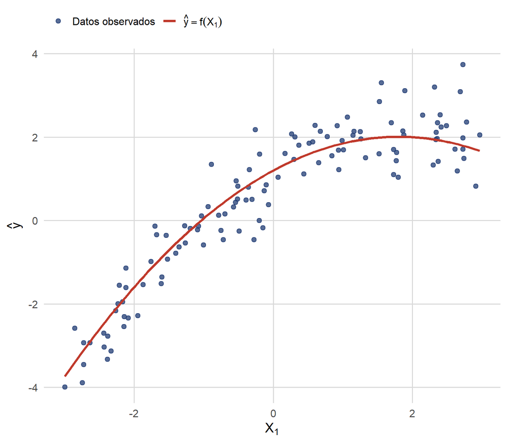

## ¿Qué es lo supervisado?

**Idea clave.** Al observar $Y$, el aprendizaje se puede *supervisar*:

- **Entrenamiento:** ajustar $f$ usando una fracción de los datos.
- **Prueba/validación:** evaluar en datos independientes comparando $\hat{y}_i$ vs. $y_i$ con una medida de error.

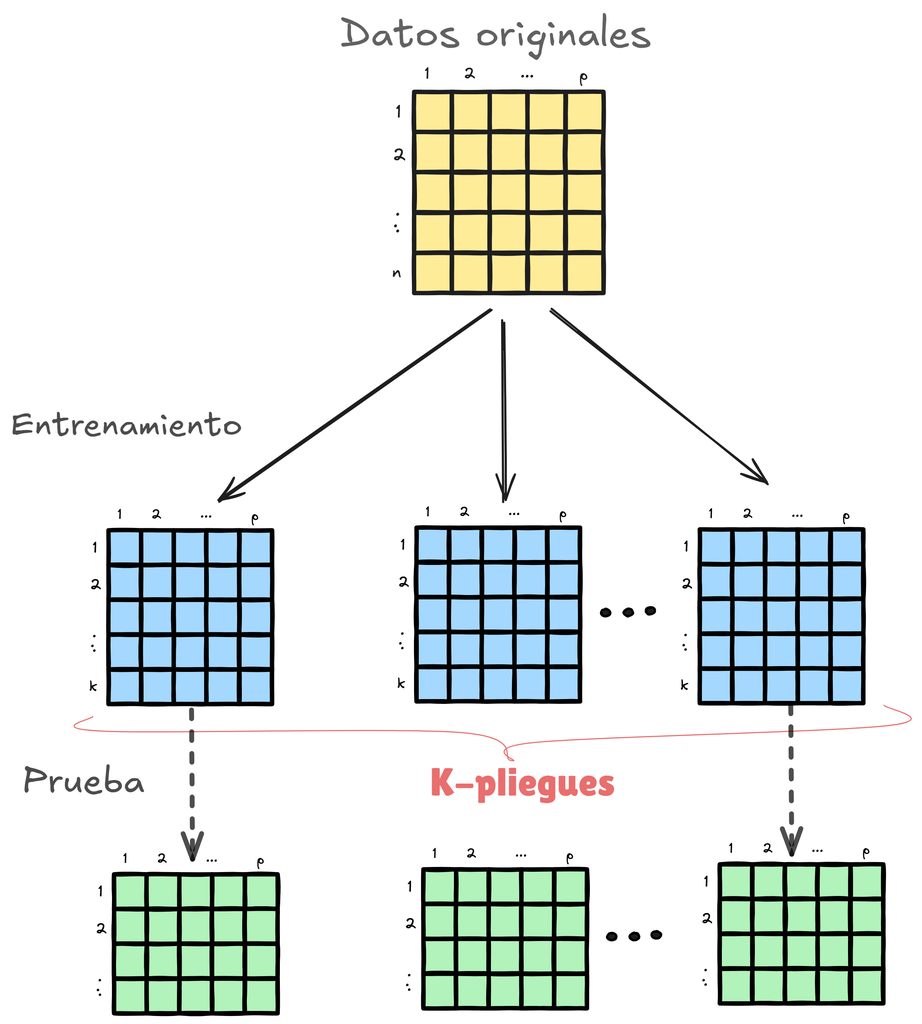

## Métodos típicos en la categoría supervisados

- **Regresión**: Regresión lineal, polinómica y regularizada (ridge/lasso).
- **Clasificación**: Regresión logística, árboles, k-NN, SVM y redes neuronales.
- **Modelos extendidos**: Modelos lineales generalizados (GLM) y aditivos generalizados (GAM).

## Contraste: Aprendizaje Supervisado vs No Supervisado

**Idea central.** En el **Aprendizaje Estadístico No Supervisado** solo se observan variables explicativas $X_1, \ldots, X_p$; no existe una variable respuesta $Y$ que permita supervisar el aprendizaje ni evaluar el ajuste mediante un criterio externo de error.

- No hay una respuesta observable que se desee predecir.
- El problema no se formula en términos de predicción supervisada.
- La evaluación del resultado es interna al método y de carácter exploratorio.

## Contraste: Aprendizaje Supervisado vs No Supervisado

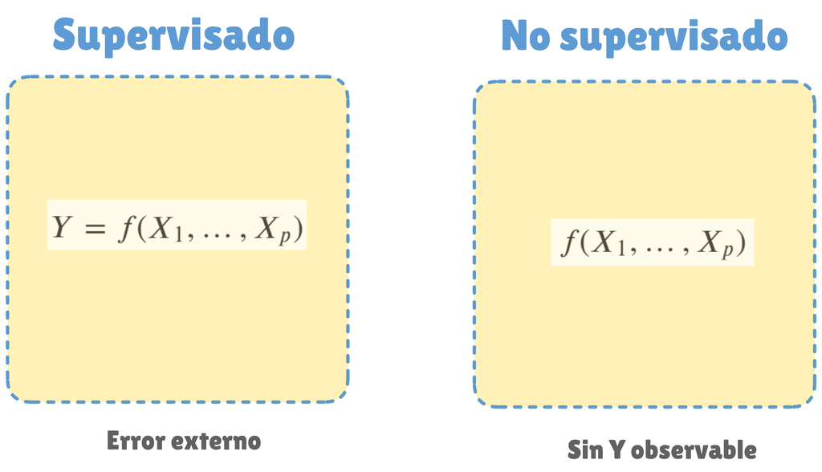

## Métodos en Aprendizaje No Supervisado

Como parte del **Aprendizaje Estadístico No Supervisado** se incluyen, entre otros, los siguientes métodos:

- **Reducción de dimensión:** Análisis de Componentes Principales (ACP).
- **Asociación en tablas categóricas:** Análisis de Correspondencias (AC) y Análisis de Correspondencias Múltiples (ACM).
- **Estructura de similitud:** métodos de agrupamiento (*clustering*).

## Ilustración en el plano factorial

[figure not shown]

## Mapa conceptual

### La estadística multivariada en el contexto del aprendizaje no supervisado

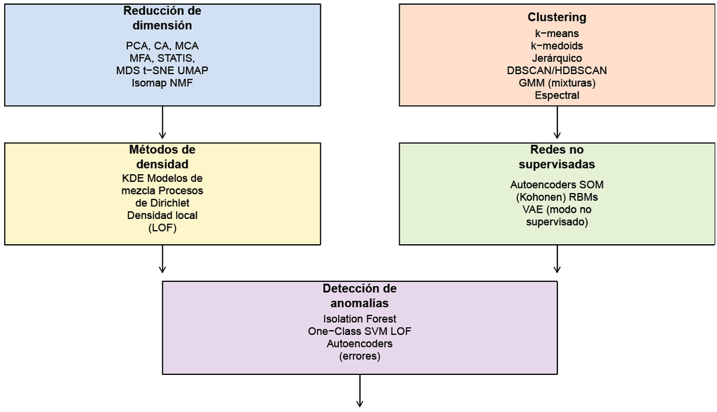

## Mapa conceptual

### La estadística multivariada en el contexto del aprendizaje no supervisado

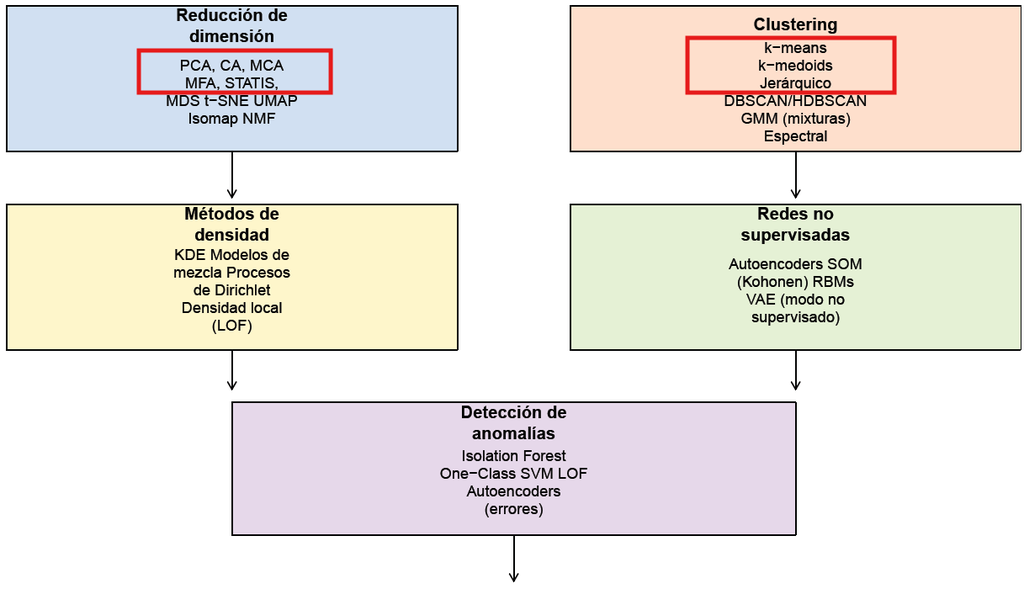

## Métodos tratados en este curso

- **PCA** (Principal Components Analysis).
- **CA** (Correspondence Analysis).
- **MCA** (Multiple Correspondence Analysis).
- **K-means**.
- **k-medoids** (Partitioning Around Medoids - PAM)
- **Clustering jerarquico** (aglomerativo o divisivo).

### Proceso iterativo no jerárquico

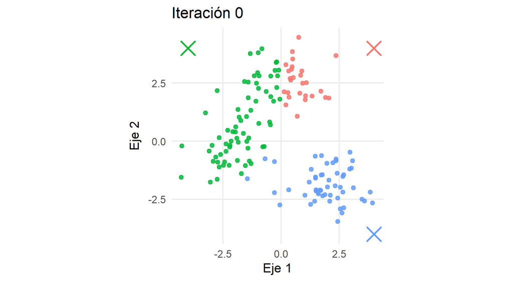

## Proceso de analítica

[Wickham, H. y otros (2023)](https://r4ds.hadley.nz/)

## Métodos de reducción de la dimensionalidad

Dos modos

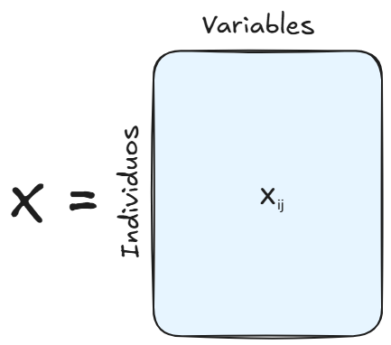

Tablas Múltiples

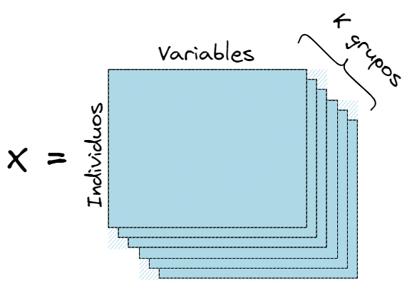

Métodos multi-way

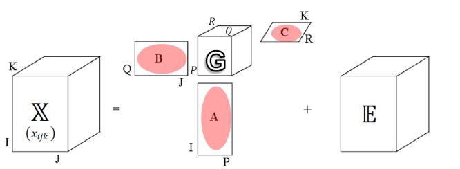

## Tipos de análisis

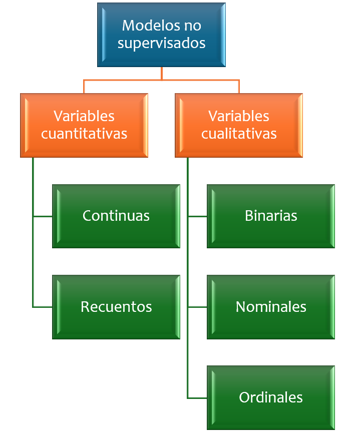

# ANÁLISIS DE COMPONENTES PRINCIPALES

## Objetivo general

Método para reducir la dimensionalidad de los datos conservando la mayor cantidad de información. El método se debe usar cuando las variables son cuantitativas y existe presencia de correlación

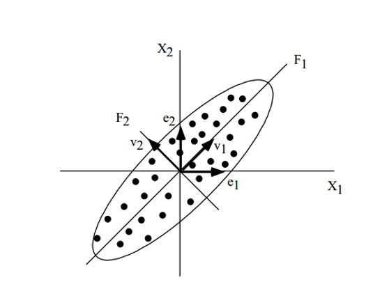

## Objetivos específicos

- **Visualizar patrones**: Sirve para visualizar la estructura de los datos y detectar patrones emergentes.
- **Construir de índices sintéticos**: Las variables originales se resumen en un conjunto menor de componentes principales que contienen información de todas las variables originales.
- **Identificar factores latentes**: Identifica los factores principales que explican los cambios relacionados con el tema de interés.
- **Identificar grupos**: Ayuda a identificar grupos de individuos que comparten características similares.

## Introducción

Sea $\mathbf{X}$ la matriz de datos, con $\mathbf{x}_i \in \mathbb{R}^p,\ i \in \{1, \dots, n\}$, que representa los valores de $p$ variables **cuantitativas** para $n$ individuos, se busca investigar si es posible representar los individuos mediante $r$ variables ($r<p$), con poca, o ninguna pérdida de información, si es posible.

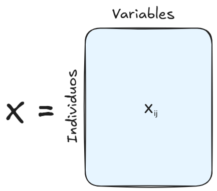

## Contexto histórico

## Orígenes

Pearson planteó un problema geométrico: encontrar una representación óptima de datos multivariados en una dimensión reducida con respecto al error cuadrático medio.

Si $\mathbf{x}_i \in \mathbb{R}^p, i \in \{1, \dots, n\}$, están centrados, el objetivo de PCA es

$$\min_{U \in \mathbb{R}^{p \times r}}
\sum_{i=1}^n \left\| \mathbf{x}_i - UU^\top \mathbf{x}_i \right\|^2
\quad \text{sujeto a} \quad
U^\top U = I_r,$$

donde $r < p$.

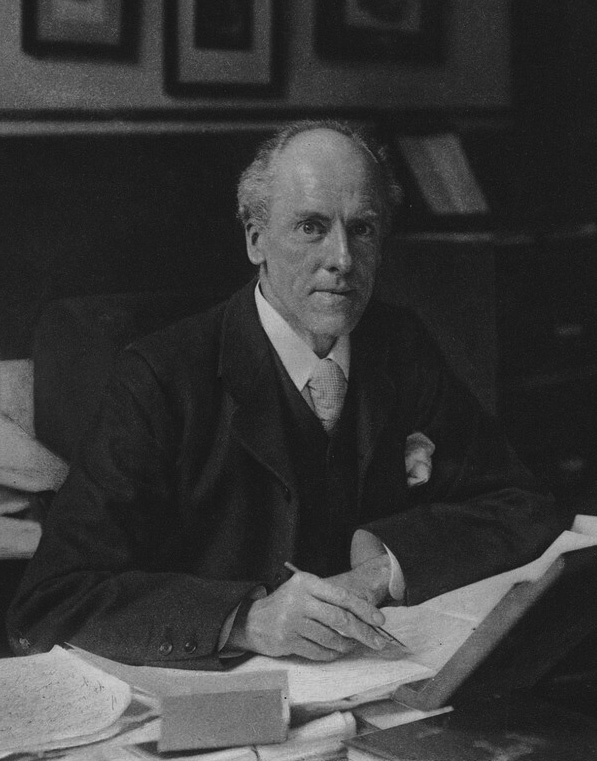

## Orígenes

Pearson planteó un problema geométrico: encontrar una representación óptima de datos multivariados en una dimensión reducida con respecto al error cuadrático medio.

Si $\mathbf{x}_i \in \mathbb{R}^p, i \in \{1, \dots, n\}$, están centrados, el objetivo de PCA es

$$\min_{U}
\| X - X U U^\top \|_F^2
\quad \text{sujeto a} \quad
U^\top U = I_r$$

donde $r < p$.

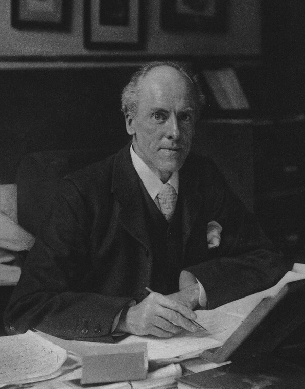

## Orígenes

Hotelling (1933) demostró que las direcciones que maximizan la varianza proyectada son los autovectores de la matriz de covarianzas muestral.

El objetivo es maximizar:

$$\max_{U \in \mathbb{R}^{p \times r}}
\operatorname{tr}\!\left(U^\top \mathbf{X}^\top \mathbf{X} U\right)
\quad \text{sujeto a} \quad
U^\top U = I_r,$$

donde $r < p$.

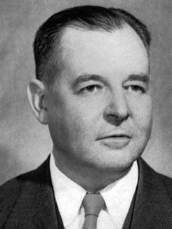

## Orígenes

Enfoque de Hotelling (1933) vs Pearson (1901)

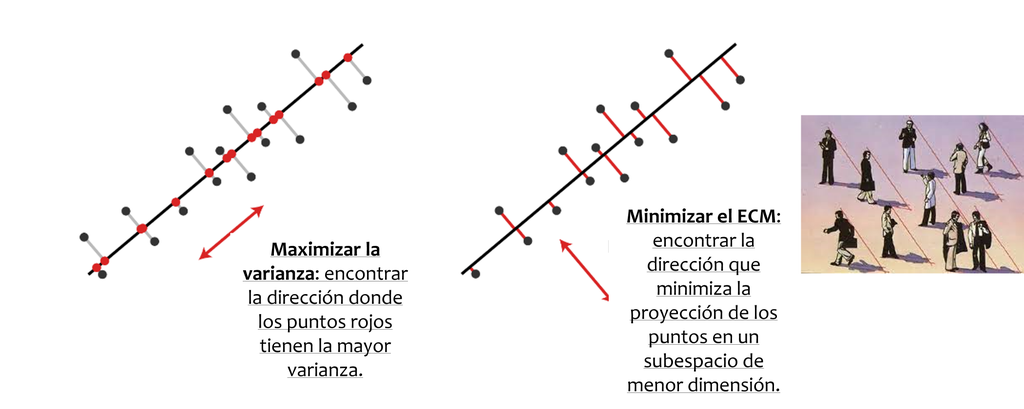

## Orígenes

Maximizar la varianza en el espacio de los componentes principales es equivalente a minimizar el error de reconstrucción por mínimos cuadrados.

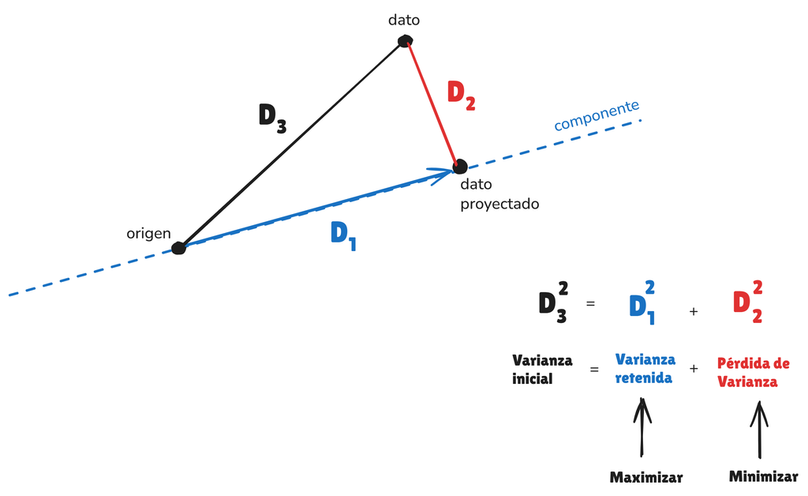

# CÁLCULO DE LAS COMPONENTES

## Formulación del problema

Sea $\mathbf{x}_i \in \mathbb{R}^p$, $i=1,\dots,n$, un conjunto de observaciones **centradas**.

El objetivo del Análisis de Componentes Principales (PCA) es encontrar un subespacio de dimensión $r < p$ que minimice el error de reconstrucción:

$$\min_{U \in \mathbb{R}^{p \times r}}
\sum_{i=1}^n
\left\|
\mathbf{x}_i - UU^\top \mathbf{x}_i
\right\|^2
\quad \text{sujeto a} \quad
U^\top U = I_r$$

donde las columnas de $U$ son ortonormales.

## Interpretación geométrica

- $UU^\top \mathbf{x}_i$ es la **proyección ortogonal** de $\mathbf{x}_i$ sobre el subespacio generado por $U$.
- El problema busca:

> El subespacio de dimensión $r$ que mejor aproxima los datos.

Equivalente a minimizar la pérdida de información.

## Forma matricial

Sea $X \in \mathbb{R}^{n \times p}$ la matriz de datos centrados. El problema es equivalente a:

$$\min_{U}
\| X - X U U^\top \|_F^2
\quad \text{sujeto a} \quad
U^\top U = I_r$$

donde $\|\cdot\|_F$ es la norma de Frobenius, es decir, $\|A\|^2_F=\operatorname{tr}\!\left(A^\top A\right)$. Entonces:

$$\min_{U}
\| X - X U U^\top \|_F^2 = \operatorname{tr}\!\left(X^\top X\right) - \operatorname{tr}\!\left(U^\top X^\top XU\right)$$

El primer término no depende de $U$.

## Problema equivalente

$$\max_{U}
\operatorname{tr}\!\left(U^\top X^\top XU\right)
\quad \text{sujeto a} \quad
U^\top U = I_r$$

Si definimos la matriz de covarianza:

$$S = \frac{1}{n} X^\top X$$

obtenemos:

$$\max_{U}
\operatorname{tr}(U^\top S U)
\quad \text{sujeto a} \quad
U^\top U = I_r$$

## Maximización por multiplicadores de Lagrange

Sea $S = \frac{1}{n}X^\top X$ la matriz de covarianzas. El problema de PCA puede escribirse como:

$$\max_{U}
\operatorname{tr}(U^\top S U)
\quad \text{sujeto a} \quad
U^\top U = I_r.$$

Construimos el Lagrangiano:

$$\mathcal{L} = \operatorname{tr}(U^\top S U) - \operatorname{tr}\!\left[\Lambda(U^\top U - I_r)\right]$$

donde $\Lambda$ es simétrica.

## Maximización por multiplicadores de Lagrange

Derivando respecto a $U$:

$$2SU - 2U\Lambda = 0$$

Por lo tanto:

$$SU = U\Lambda.$$

Esto implica que:

$$S u_k = \lambda_k u_k,
\quad k=1,\dots,r.$$

Las columnas de $U$ son los autovectores de $S$ asociados a los mayores autovalores.

## Interpretación

Para una dirección unitaria $u$:

$$\mathrm{Var}(Xu) = u^\top S u.$$

PCA busca:

$$\max_{\|u\|=1} u^\top S u.$$

Por lo tanto:

- Primera componente → máxima varianza
- Segunda → máxima varianza restante
- Direcciones ortogonales

## Componentes Principales

Las componentes principales se obtienen como:

$$Z = XU$$

Reconstrucción de los datos:

$$\hat X = ZU^\top$$

Interpretación:

- $U$ → direcciones principales
- $Z$ → coordenadas en el nuevo sistema

## Descripción del ACP

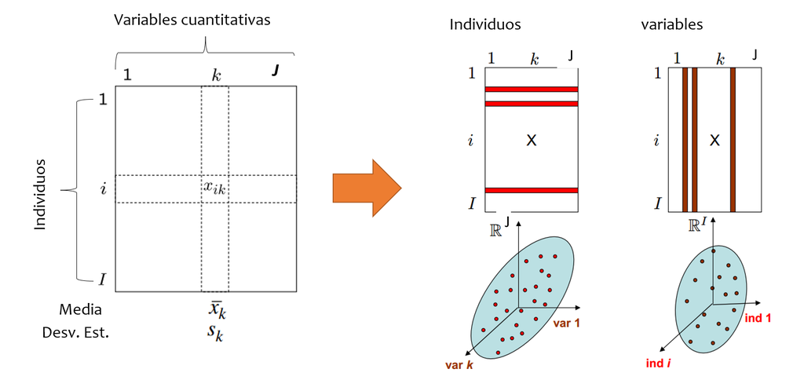

## Descripción del ACP

Reproducir la matriz original usando menos dimensiones

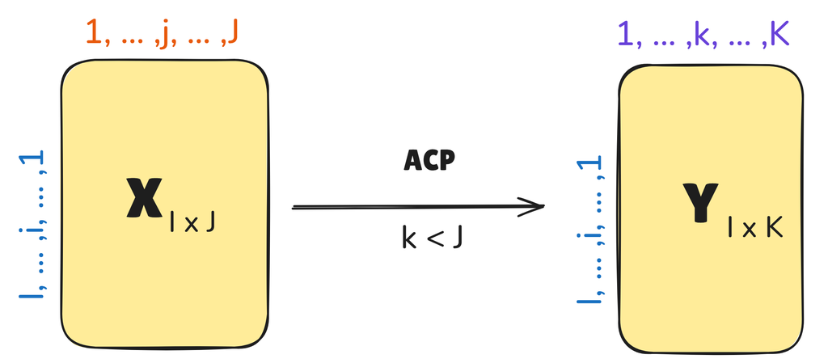

## Teorema de la factorización - SDV

El primer artículo sobre descomposición en valores singulares (SVD) fue publicado en Psychometrika (Eckart y Young, 1936).

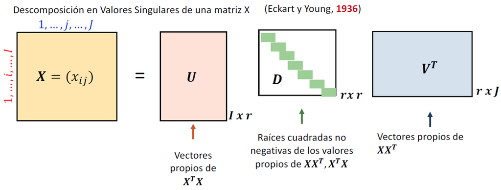

## Esquema de las componentes

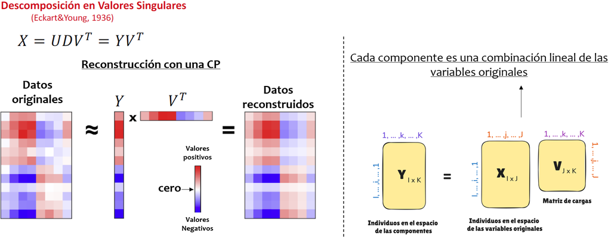

## Interpretación en el espacio de las componentes

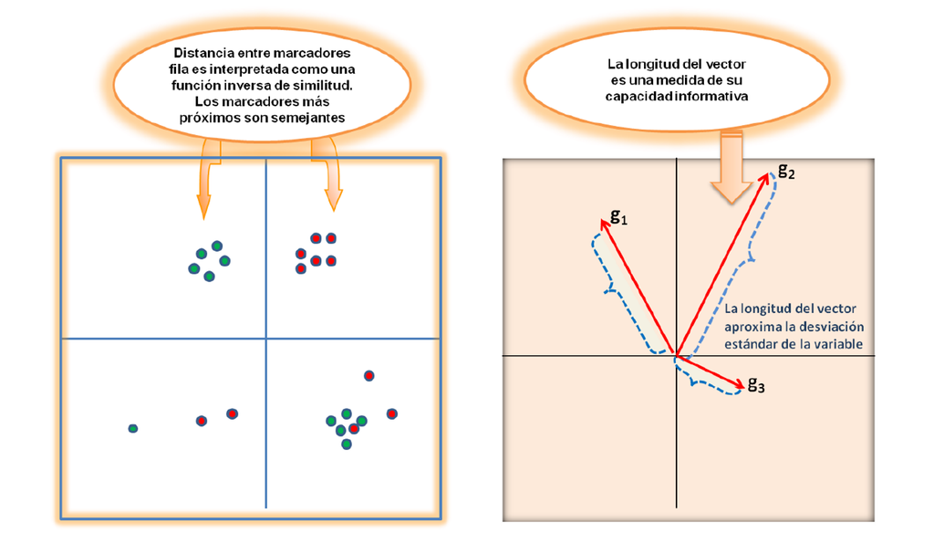

## Interpretación en el espacio de las componentes

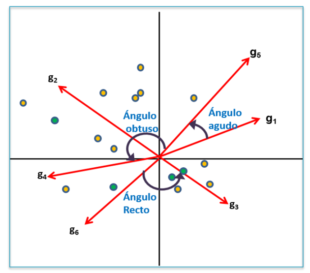

# PROPIEDADES DE LAS COMPONENTES

# EJEMPLO

## Gran Encuesta Integrada de Hogares - GEIH

El conjunto de datos `RESUMEN.sav` contiene un preprocesamiento obtenido de la GEIH del DANE a nivel departamental para algunas variables de interés.

```r
library(pacman)
p_load(tidyverse, janitor,
       FactoMineR, factoextra, Factoshiny,
       skimr, corrplot, psych, haven)

url <- "https://github.com/jgbabativam/AnaDatos/raw/main/datos/RESUMEN.sav"
datos <- read_sav(url) |> as_factor()
```

Use el comando `glimpse()` y `skim()` para explorar el conjunto de datos.

## Preparación del conjunto de datos

EL ACP es una técnica que se aplica sobre variables cuantitativas.

- Correlación
- Código

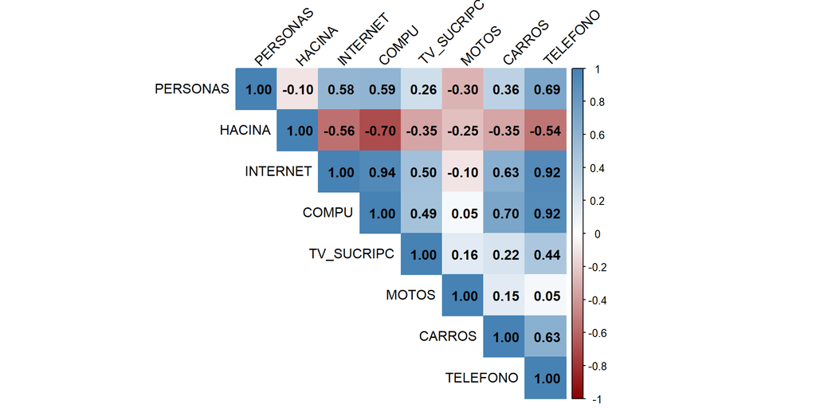

```r
datos <- datos |>
         column_to_rownames(var = "DPTO")


corrplot(datos |> cor(),
         method = "color", type = "upper", addCoef.col = "black", tl.col = "black", tl.srt = 45,
         col = colorRampPalette(c("darkred", "white", "steelblue"))(200))
```

## Varianza explicada por las componentes

```r
res <- PCA(datos, scale.unit = T, graph = F)
fviz_screeplot(res, addlabels = TRUE, ylim = c(0, 60))
```

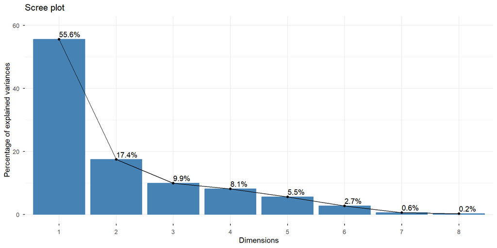

## Análisis de las contribuciones

```r
corrplot(res$var$contrib, is.corr=FALSE, tl.col = "black")
```

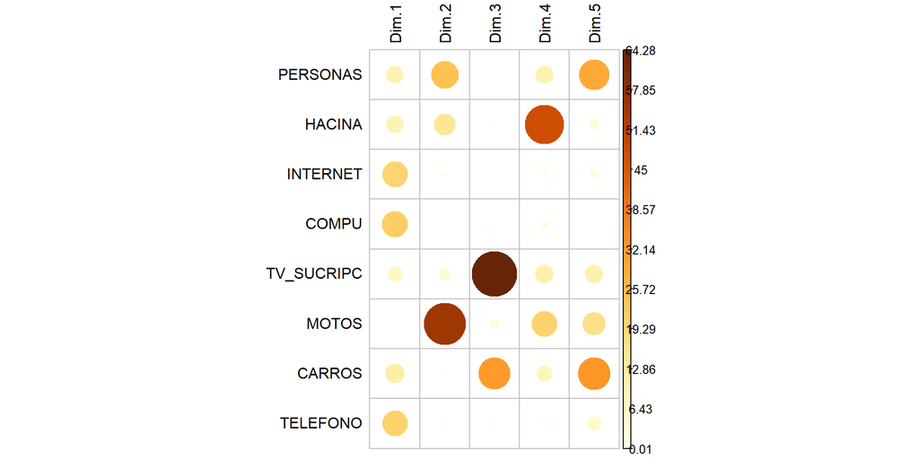

## Análisis correlación variable factor

```r
corrplot(res$var$cor, is.corr=FALSE, tl.col = "black")
```

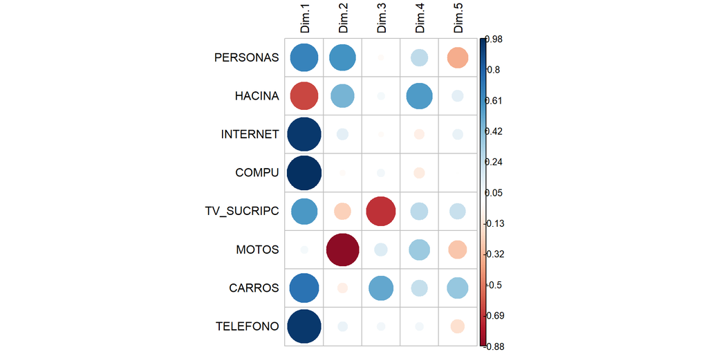

## Análisis de los cos2

Capacidad de los factores para explicar las variables

```r
corrplot(res$var$cos2, is.corr=FALSE, tl.col = "black")
```

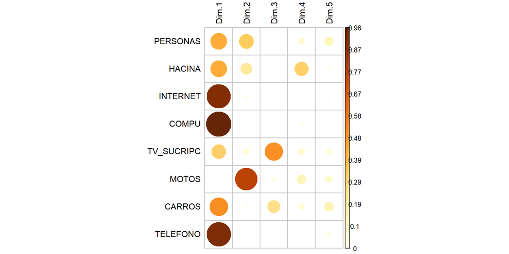

## Primer plano factorial para las variables

```r
fviz_pca_var(res,
             col.var="contrib",
             gradient.cols = c("#00AFBB", "#E7B800", "#FC4E07"),
             repel = TRUE)
```

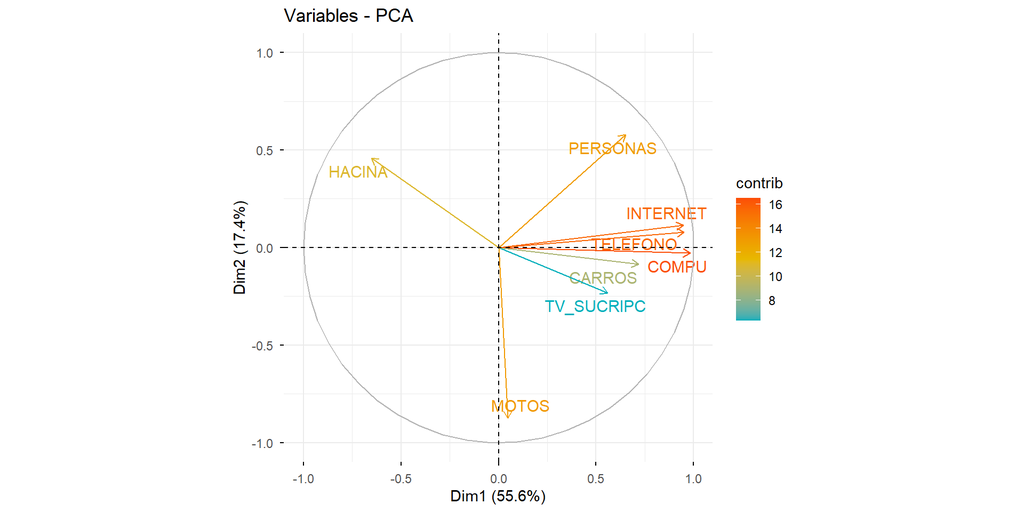

## Primer plano factorial para los individuos

```r
fviz_pca_ind(res, col.ind = "cos2",
             gradient.cols = c("#00AFBB", "#E7B800", "#FC4E07"),
             repel = TRUE)
```

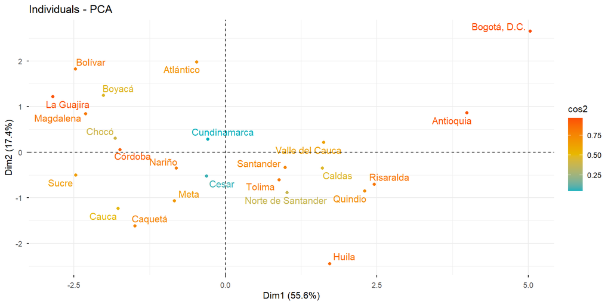

## Biplot

```r
fviz_pca_biplot(res, repel = TRUE, col.ind = "blue", col.var = "red")
```

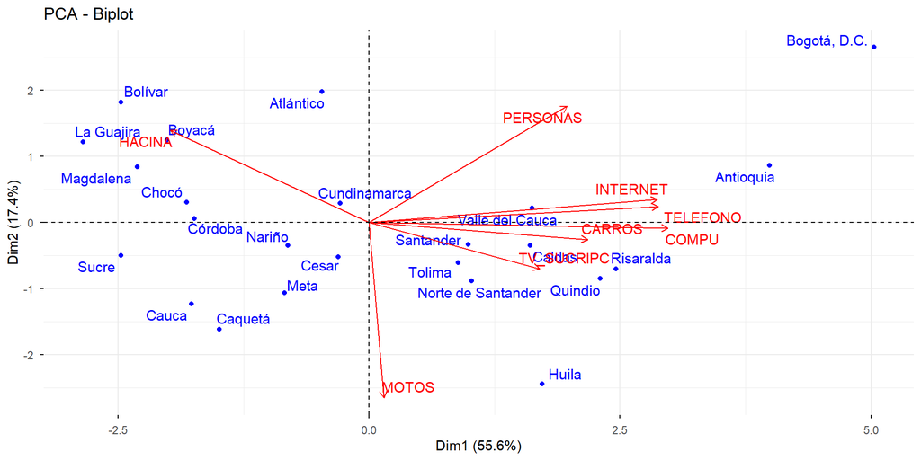

## Construcción de índices sintéticos

Teniendo en cuenta que:

$$\mathbf{Z} = \mathbf{XU}$$

Entonces una CP es una variable latente que resume la información contenida en las variables originales. Por ejemplo, la primera CP es:

$$z_{1i} = u_{11} \cdot x_{1i} + \cdots +u_{1p} \cdot x_{pi}$$

La matriz $\mathbf{U}$ actúa como los ponderadores de las variables de la matriz $\mathbf{X}$, con lo cual $\mathbf{Z}$ es un índice que resume la información contenida en las variables originales. Como cada CP está incorrelacionada con las demás, entonces la información que explica cada una es diferente.